# [STAT 4540] HW-2

Michael Ghattas

2/9/2022

# Problem 1

$X_{t} + \frac{5}{4} X_{t - 1} = \frac{1}{2} \tilde{Z}_{t} + \frac{3}{4} \tilde{Z}_{t - 1}$

let $Z_{t} = \frac{1}{2} \tilde{Z}_{t}$

$\tilde{Z}_{t} \sim wn(0, \sigma^2) \to Z_{t} \sim wn(0, \frac{1}{4} \sigma^2)$

$\to \frac{1}{2} \tilde{Z}_{t} + \frac{3}{4} \tilde{Z}_{t - 1} = Z_{t} + \frac{\frac{3}{4}}{2} Z_{t - 1} = Z_{t} + \frac{3}{8} Z_{t - 1}$

$\to X_{t} + \frac{5}{4} X_{t - 1} = Z_{t} + \frac{3}{8} Z_{t - 1}$

Let $\frac{5}{4} X_{t - 1} = -(-\frac{5}{4}) X_{t - 1}$

$\to X_{t} - (-\frac{5}{4}) X_{t - 1} = Z_{t} + \frac{3}{8} Z_{t - 1}$

### (a)

Given the below points, we can conclude that there exists a unique and stationary solution for $\{X_{t}\}$:

1. $X_{t} - (-\frac{5}{4}) X_{t - 1} = Z_{t} + \frac{3}{8} Z_{t - 1}$
2. $\phi = -\frac{5}{4}$ and $\theta = \frac{3}{8} \to \phi + \theta = \frac{3}{8} - \frac{5}{4} = \frac{3 - 10}{8} = -\frac{7}{8} \neq 0$
3. $\phi = -\frac{5}{4} \to |\phi| \neq 1$

### (b)

Given that $\phi = -\frac{5}{4} \to |\phi| > 1$, thus the process is non-causal.

### (c)

Given that $\theta = \frac{3}{8} \to |\theta| < 1$, thus the process is invertible.

### (d)

$X_{t} - (-\frac{5}{4}) X_{t - 1} = Z_{t} + \frac{3}{8} Z_{t - 1}$

$$\begin{align*}
X_{t} &= - (\frac{\frac{3}{8}}{-\frac{5}{4}}) Z_{t} - (\frac{3}{8} + (- \frac{5}{4})) \sum_{j = 0}^{1} \frac{1}{\phi^{j + 1}} Z_{t + j} \\
&= - (- \frac{40}{12}) Z_{t} - (\frac{3}{8} - \frac{5}{4}) \sum_{j = 0}^{1} \frac{1}{(\frac{5}{4})^{j + 1}} Z_{t + j} \\
&= \frac{40}{12} Z_{t} - (\frac{3 - 10}{8}) \cdot (\frac{Z_{t + 0}}{(\frac{5}{4})^{0 + 1}} + \frac{Z_{t + 1}}{(\frac{5}{4})^{1 + 1}}) \\
&= \frac{10}{3} Z_{t} - (-\frac{7}{8}) \cdot (\frac{Z_{t}}{(\frac{5}{4})^{1}} + \frac{Z_{t + 1}}{(\frac{5}{4})^{2}}) \\
&= \frac{10}{3} Z_{t} + \frac{7}{8} \cdot (\frac{Z_{t}}{\frac{5}{4}} + \frac{Z_{t + 1}}{\frac{25}{26}}) \\
&= \frac{10}{3} Z_{t} + \frac{7}{8} \cdot (\frac{4}{5} Z_{t} + \frac{25}{16} Z_{t + 1}) \\
&= \frac{10}{3} Z_{t} + \frac{28}{40} Z_{t} + \frac{175}{128} Z_{t + 1} \\
&= (\frac{100 + 21}{30}) Z_{t} + \frac{175}{128} Z_{t + 1} \\
&= \frac{121}{30} Z_{t} + \frac{175}{128} Z_{t + 1} \\
&= \frac{121}{30} \cdot (\frac{1}{2} \tilde{Z}_{t}) + \frac{175}{128} \cdot (\frac{1}{2} \tilde{Z}_{t + 1}) \\
&= \frac{121}{60} \tilde{Z}_{t} + \frac{175}{256} \tilde{Z}_{t + 1} \\
\end{align*}$$

Thus: $X_{t} = \frac{121}{60} \tilde{Z}_{t} + \frac{175}{256} \tilde{Z}_{t + 1}$.

# Problem 2

### (a)

The big picture is filtering the estimated trend from the data through filtering out until we are left with nothing but residuals that are stationary.

### (b)

No, the shift by re-indexing should have not affect any significant change.

### (c)

The condition should not depend on the indexing choice, however the output would change if we redefined the indexing sequence.

# Problem 3

### (a)

```r
library(lubridate)
```

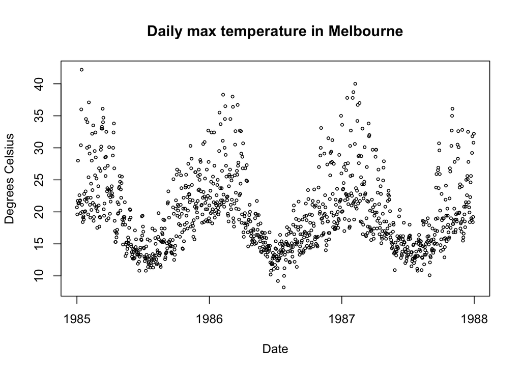

```r
library(gridExtra)
library(ggplot2)
library(dplyr)
data <- load("/Users/Home/Documents/Michael_Ghattas/School/CU_Boulder/2022/Spring 2022/STAT - 4540/HW/2/DailyMaxMelbourne19851987.RData")
dates = as.Date(dates,format = "%m/%d/%y")
df = data.frame(dates, temp)
plot(dates, temp, xlab = "Date", ylab = "Degrees Celsius", main = "Daily max temperature in Melbourne", pch = 01, cex = 0.5)
```

### (b)

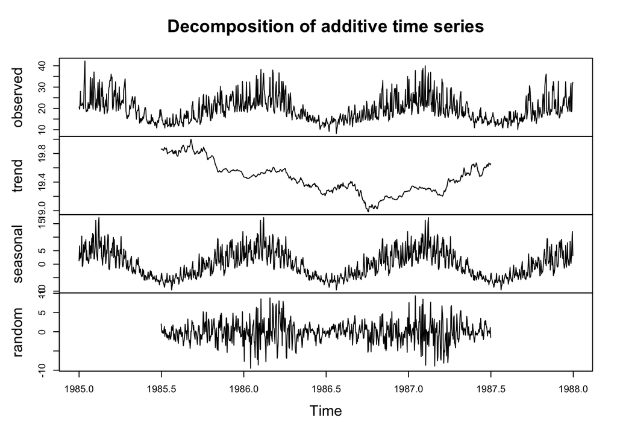

```r
df.ts <- ts(data = df$temp, start = c(1985, 1), end = c(1987, 365), frequency = 365)
out <- decompose(df.ts, type = "additive")
plot(out)
```

We can see that the decomposition did not work well, as the results are to noisy. An appropriate filter is needed prior to the decompose function.

### (c)

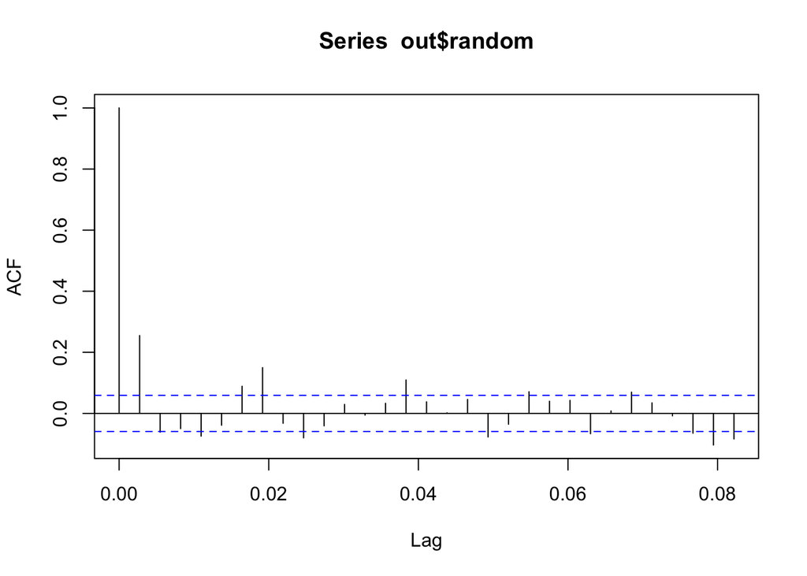

```r
acf(out$random, na.action = na.pass)
```

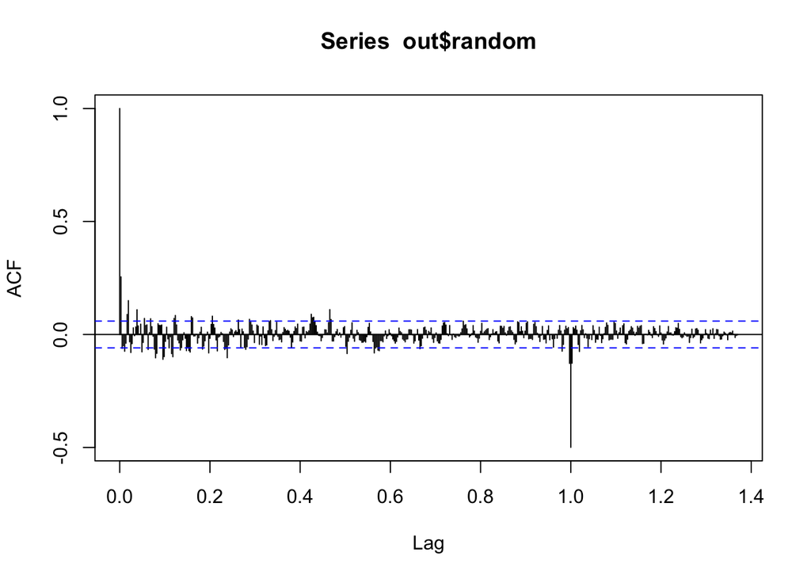

```r
acf(out$random, na.action = na.pass, lag.max = 500)
```

The results present moderate correlation, thus further filtering is needed to be able to identify white noise. A low-degree polynomial based regression model might be helpful.

### (d)

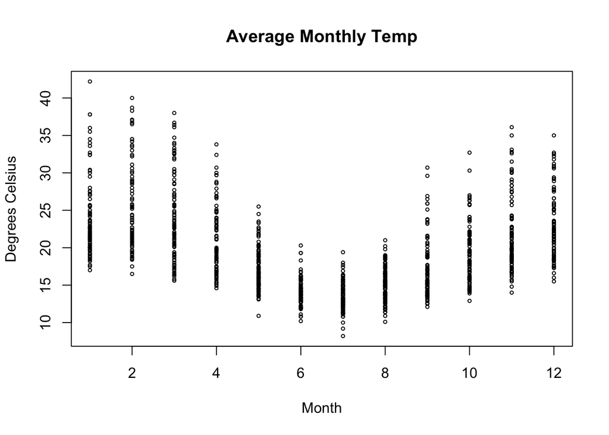

```r
df$year <- year(df$dates)
df$month <- month(df$dates)

avgtemp <- aggregate(temp ~ year + month, df, mean)
avgtemp$date = as.Date(paste(avgtemp$year, avgtemp$month, 01), "%y %m %d")
avgtemp = arrange(avgtemp, date)

avgtemp.ts <- ts(data = avgtemp$temp, start = c(1985, 1), end = c(1987, 12), frequency = 12)
avgtemp.out <- decompose(df.ts, type = "additive")

plot(df$month, temp, xlab = "Month", ylab = "Degrees Celsius", main = "Average Monthly Temp", pch = 01, cex = 0.5)
```

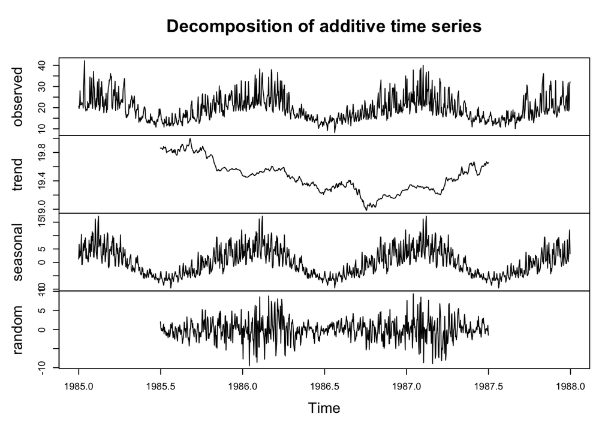

```r
plot(avgtemp.out)
```

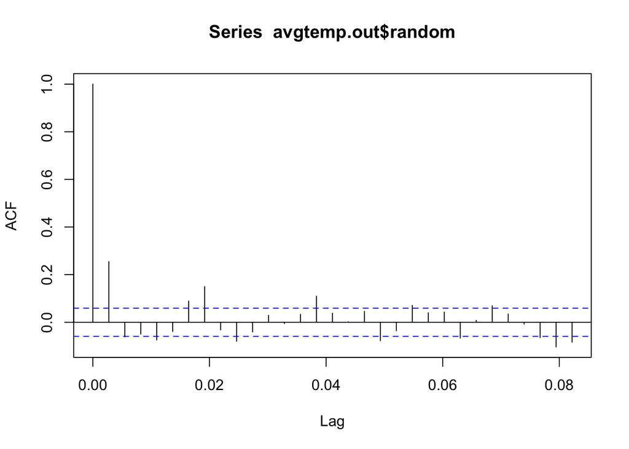

```r
acf(avgtemp.out$random, na.action = na.pass)
```

From the data we can see a correlation between the month and average temperature. We can also see a relationship between the the average temperature of each month in relation to the previous month. Additional filtering is needed to extract trends, seasonality and noise.

# Problem 4

### (a)

$$\begin{align*}
Z_{t} &= (1 - B)(1 - B^{12})Y_{t} \\
&= (1 - B - B^{12} + B^{13})Y_{t} \\
&= Y_{t} - Y_{t - 1} - Y_{t - 12} + Y_{t - 13} \\
&= (Y_{t} - Y_{t - 12}) - (Y_{t - 1} - Y_{t - 13}) \\
&= (a + bt + s_{t} + X_{t} - a - b(t - 12) - s_{t - 12} - X_{t - 12}) - (a + b(t - 1) + s_{t - 1} + X_{t - 1} - a - b(t - 13) - s_{t - 13} - X_{t - 13}) \\
&= (bt + X_{t} - b(t - 12) - X_{t - 12}) - (b(t - 1) + X_{t - 1} - b(t - 13) - X_{t - 13}) \\
&= (X_{t} - X_{t - 12} + 12b) - (X_{t - 1} - X_{t - 13} + 13b) \\
&= X_{t} - X_{t - 12} + 12b - X_{t - 1} + X_{t - 13} - 13b) \\
&= X_{t} - X_{t - 1} - X_{t - 12} + X_{t - 13} - b \\
&= X_{t} - X_{t - 1} - X_{t - 12} + X_{t - 13} \\
\end{align*}$$

Thus: $Z_{t} = X_{t} - X_{t - 1} - X_{t - 12} + X_{t - 13}$ satisfies an AR(p) stationary process.